# Simple Linear Regression Analysis

Mohammad Ali Momen

05/03/2023

**Data Analysis methodology**: CRISP-DM

**Dataset**: Toyota Used Cars certified features and dealing (sold) prices in Europe

**Case Goal**: Price Recommendation Intelligence System for Toyota Used Cars in Europe Trading Platform

# 1 Required Libraries

```r
library('ggplot2')
library('car')
library('corrplot')
library('moments')
```

# 2 Read Data from File

```r
data <- read.csv('CS_03.csv', header = T)
dim(data)  # 1325 records, 10 variables
```

```
## [1] 1325   10
```

# 3 Business Understanding

- know business process and issues
- know the context of the problem
- know the order of numbers in the business

# 4 Data Understanding

## 4.1 Data Inspection

Data Understanding from Free Perspective

### 4.1.1 Dataset variables definition

```r
colnames(data)
```

```
##  [1] "Price"     "Age"       "KM"        "FuelType"  "HP"        "MetColor"
##  [7] "Automatic" "CC"        "Doors"     "Weight"
```

- **Price**: Sales (sold) price in Euro -> what we want to predict
- **Age**: Age of a used car in month
- **KM**: Kilometerage usage
- **FuelType**: Petrol, Diesel, CNG -> Categorical (factor)
- **HP**: Horse power
- **MetColor**: -> Categorical (factor)
  - 1 = if Metallic color
  - 0 = Not
- **Automatic**: -> Categorical (factor)
  - 1 = if Automatic
  - 0 = Not
- **CC**: Engine displacement in cc
- **Doors**: # of doors -> Categorical (factor)
- **Weight**: Weight in Kilogram

## 4.2 Data Exploring

Data Understanding from Statistical Perspective

### 4.2.1 Overview of Dataframe

```r
class(data)
```

```
## [1] "data.frame"
```

```r
head(data)
```

|  | Price | Age | KM | FuelType | HP | MetColor | Automatic | CC | Doors | Weight |
| --- | --- | --- | --- | --- | --- | --- | --- | --- | --- | --- |
| 1 | 13500 | 23 | 46986 | Diesel | 90 | 1 | 0 | 2000 | 3 | 1165 |
| 2 | 13750 | 23 | 72937 | Diesel | 90 | 1 | 0 | 2000 | 3 | 1165 |
| 3 | 13950 | 24 | 41711 | Diesel | 90 | 1 | 0 | 2000 | 3 | 1165 |
| 4 | 14950 | 26 | 48000 | Diesel | 90 | 0 | 0 | 2000 | 3 | 1165 |
| 5 | 13750 | 30 | 38500 | Diesel | 90 | 0 | 0 | 2000 | 3 | 1170 |
| 6 | 12950 | 32 | 61000 | Diesel | 90 | 0 | 0 | 2000 | 3 | 1170 |

```r
tail(data)
```

|  | Price | Age | KM | FuelType | HP | MetColor | Automatic | CC | Doors | Weight |
| --- | --- | --- | --- | --- | --- | --- | --- | --- | --- | --- |
| 1320 | 8450 | 80 | 23000 | Petrol | 86 | 0 | 0 | 1300 | 3 | 1015 |
| 1321 | 7500 | 69 | 20544 | Petrol | 86 | 1 | 0 | 1300 | 3 | 1025 |
| 1322 | 10845 | 72 | 19000 | Petrol | 86 | 0 | 0 | 1300 | 3 | 1015 |
| 1323 | 8500 | 71 | 17016 | Petrol | 86 | 0 | 0 | 1300 | 3 | 1015 |
| 1324 | 7250 | 70 | 16916 | Petrol | 86 | 1 | 0 | 1300 | 3 | 1015 |
| 1325 | 6950 | 76 | 1 | Petrol | 110 | 0 | 0 | 1600 | 5 | 1114 |

```r
str(data)
```

```
## 'data.frame':    1325 obs. of  10 variables:
##  $ Price    : int  13500 13750 13950 14950 13750 12950 16900 12950 16750 16950 ...
##  $ Age      : int  23 23 24 26 30 32 27 23 24 30 ...
##  $ KM       : int  46986 72937 41711 48000 38500 61000 94612 71138 25563 64359 ...
##  $ FuelType : chr  "Diesel" "Diesel" "Diesel" "Diesel" ...
##  $ HP       : int  90 90 90 90 90 90 90 69 110 110 ...
##  $ MetColor : int  1 1 1 0 0 0 1 0 0 1 ...
##  $ Automatic: int  0 0 0 0 0 0 0 0 0 0 ...
##  $ CC       : int  2000 2000 2000 2000 2000 2000 2000 1900 1600 1600 ...
##  $ Doors    : int  3 3 3 3 3 3 3 3 3 3 ...
##  $ Weight   : int  1165 1165 1165 1165 1170 1170 1245 1105 1065 1105 ...
```

```r
summary(data)
```

```
##      Price            Age              KM           FuelType
##  Min.   : 4350   Min.   :13.00   Min.   :     1   Length:1325
##  1st Qu.: 8250   1st Qu.:50.00   1st Qu.: 47211   Class :character
##  Median : 9500   Median :62.00   Median : 66000   Mode  :character
##  Mean   : 9939   Mean   :59.19   Mean   : 72339
##  3rd Qu.:10995   3rd Qu.:71.00   3rd Qu.: 89800
##  Max.   :16950   Max.   :80.00   Max.   :243000
##        HP           MetColor        Automatic             CC
##  Min.   : 69.0   Min.   :0.0000   Min.   :0.00000   Min.   :1300
##  1st Qu.: 86.0   1st Qu.:0.0000   1st Qu.:0.00000   1st Qu.:1400
##  Median :110.0   Median :1.0000   Median :0.00000   Median :1600
##  Mean   :100.4   Mean   :0.6642   Mean   :0.05358   Mean   :1558
##  3rd Qu.:110.0   3rd Qu.:1.0000   3rd Qu.:0.00000   3rd Qu.:1600
##  Max.   :116.0   Max.   :1.0000   Max.   :1.00000   Max.   :2000
##      Doors           Weight
##  Min.   :2.000   Min.   :1000
##  1st Qu.:3.000   1st Qu.:1035
##  Median :4.000   Median :1060
##  Mean   :4.002   Mean   :1065
##  3rd Qu.:5.000   3rd Qu.:1079
##  Max.   :5.000   Max.   :1615
```

### 4.2.2 Categorical variables should be stored as factor

```r
cat_var <- c('FuelType', 'MetColor', 'Automatic', 'Doors')
data[, cat_var] <- lapply(data[, cat_var], factor)

summary(data)
```

```
##      Price            Age              KM           FuelType          HP
##  Min.   : 4350   Min.   :13.00   Min.   :     1   CNG   :  17   Min.   : 69.0
##  1st Qu.: 8250   1st Qu.:50.00   1st Qu.: 47211   Diesel: 132   1st Qu.: 86.0
##  Median : 9500   Median :62.00   Median : 66000   Petrol:1176   Median :110.0
##  Mean   : 9939   Mean   :59.19   Mean   : 72339                 Mean   :100.4
##  3rd Qu.:10995   3rd Qu.:71.00   3rd Qu.: 89800                 3rd Qu.:110.0
##  Max.   :16950   Max.   :80.00   Max.   :243000                 Max.   :116.0
##  MetColor Automatic       CC       Doors       Weight
##  0:445    0:1254    Min.   :1300   2:  2   Min.   :1000
##  1:880    1:  71    1st Qu.:1400   3:593   1st Qu.:1035
##                     Median :1600   4:130   Median :1060
##                     Mean   :1558   5:600   Mean   :1065
##                     3rd Qu.:1600           3rd Qu.:1079
##                     Max.   :2000           Max.   :1615
```

> We have few data|sample in **CNG** category of **FuelType** -> it can affect on price prediction of this cars category

> We have few data|sample in **1** category of **Automatic** -> it can affect on price prediction of this cars category

### 4.2.3 Univariate Profiling

Check each variable individually

#### 4.2.3.1 Categorical variables

Check to sure that have good car distribution in each category

```r
table(data$FuelType)  # CNG cars sample size is very small -> 17/nrow(data) < 0.05
```

```
##
##    CNG Diesel Petrol
##     17    132   1176
```

```r
table(data$MetColor)
```

```
##
##   0   1
## 445 880
```

```r
table(data$Automatic)
```

```
##
##    0    1
## 1254   71
```

```r
table(data$Doors)  # 2-door cars sample size is very small -> 2/nrow(data) < 0.05
```

```
##
##   2   3   4   5
##   2 593 130 600
```

```r
data[data$Doors == 2,]  # abnormality (error in data recording process)
```

|  | Price | Age | KM | FuelType | HP | MetColor | Automatic | CC | Doors | Weight |
| --- | --- | --- | --- | --- | --- | --- | --- | --- | --- | --- |
| 651 | 8250 | 65 | 80000 | Petrol | 86 | 1 | 0 | 1300 | 2 | 1015 |
| 968 | 7950 | 71 | 139145 | Diesel | 73 | 0 | 0 | 2000 | 2 | 1115 |

#### 4.2.3.2 Continuous variables

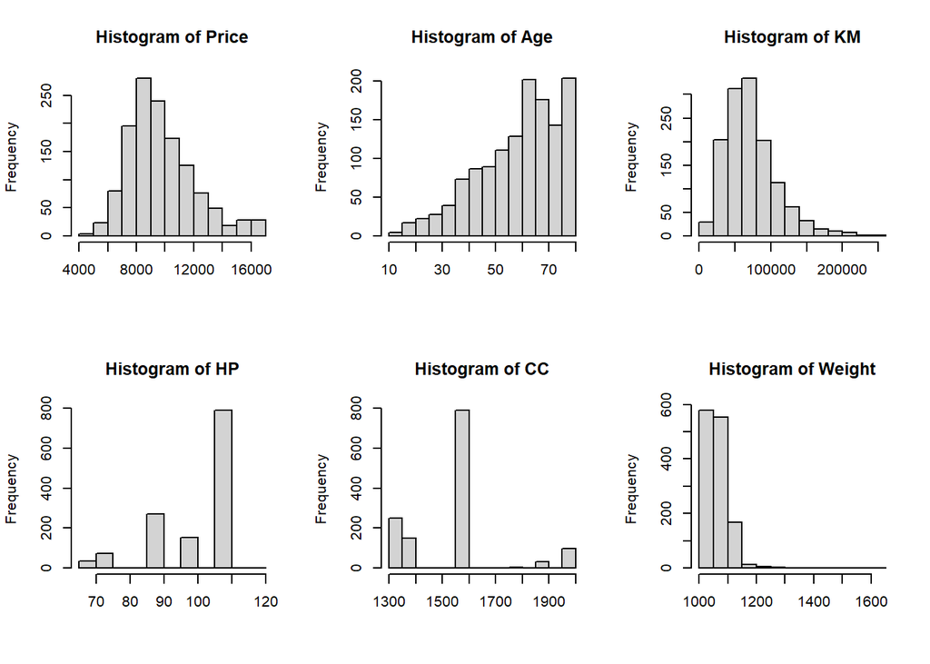

```r
par(mfrow = c(2, 3))
for(i in c(1, 2, 3, 5, 8, 10)){
    hist(data[,i], xlab='', main=paste('Histogram of', colnames(data)[i]))  # plot 6 histogram of continuous variables in one chart
}  # 'Price' is skewed to right
```

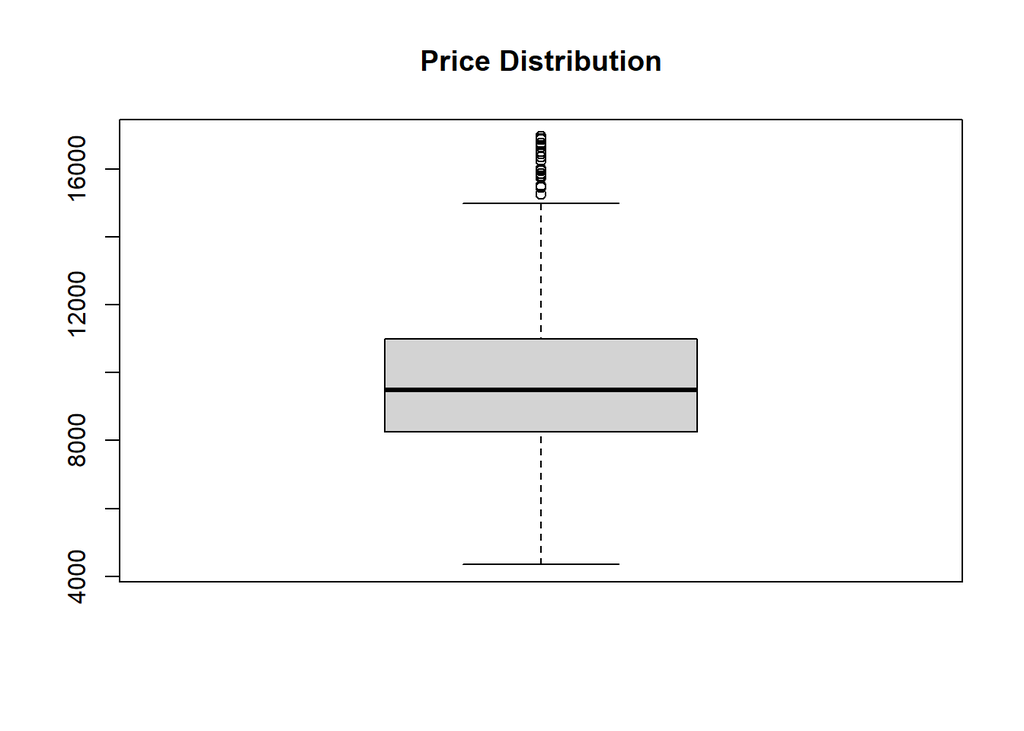

```r
par(mfrow = c(1, 1))

boxplot(data$Price, main='Price Distribution')  # outlier detection by Tukey method in Price
```

### 4.2.4 Bivariate Profiling

Measure 2-2 relationships between variables

#### 4.2.4.1 Two Continuous variables (Correlation Analysis)

```r
cor(data$Price, data$KM)  # high correlation for this context (Used Car price)
```

```
## [1] -0.5196541
```

```r
cor_table <- round(cor(data[,c(1, 2, 3, 5, 8, 10)]), 2)  # correlation table between price and continuous variables
cor_table   # choose continuous variables which have high corr with price and consider them as feature in regression model (which variable is important for price prediction)
```

```
##        Price   Age    KM    HP    CC Weight
## Price   1.00 -0.84 -0.52  0.20  0.01   0.29
## Age    -0.84  1.00  0.39 -0.05 -0.05  -0.27
## KM     -0.52  0.39  1.00 -0.33  0.39   0.19
## HP      0.20 -0.05 -0.33  1.00 -0.02  -0.08
## CC      0.01 -0.05  0.39 -0.02  1.00   0.66
## Weight  0.29 -0.27  0.19 -0.08  0.66   1.00
```

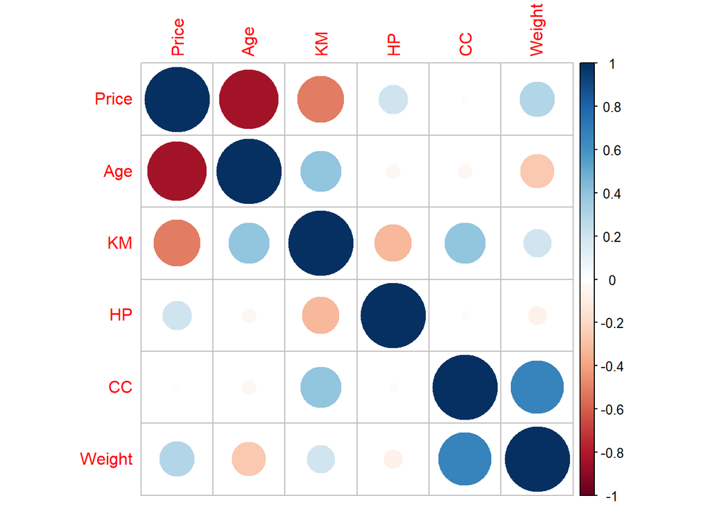

```r
corrplot(cor_table)
```

> **CC** has very small corr with **price**, so it can not be good predictor in modeling

*Multicollinearity* (having high correlation between predictor variables):

abs(corr) >= 0.30: Multicollinearity problem danger!

- **Weight** has 0.66 corr with **CC**
- **KM** has 0.39 corr with **Age**
- **KM** has 0.39 corr with **CC**
- **KM** has -0.33 corr with **HP**

Scatter Plot (between price and other continuous variables 2 by 2)

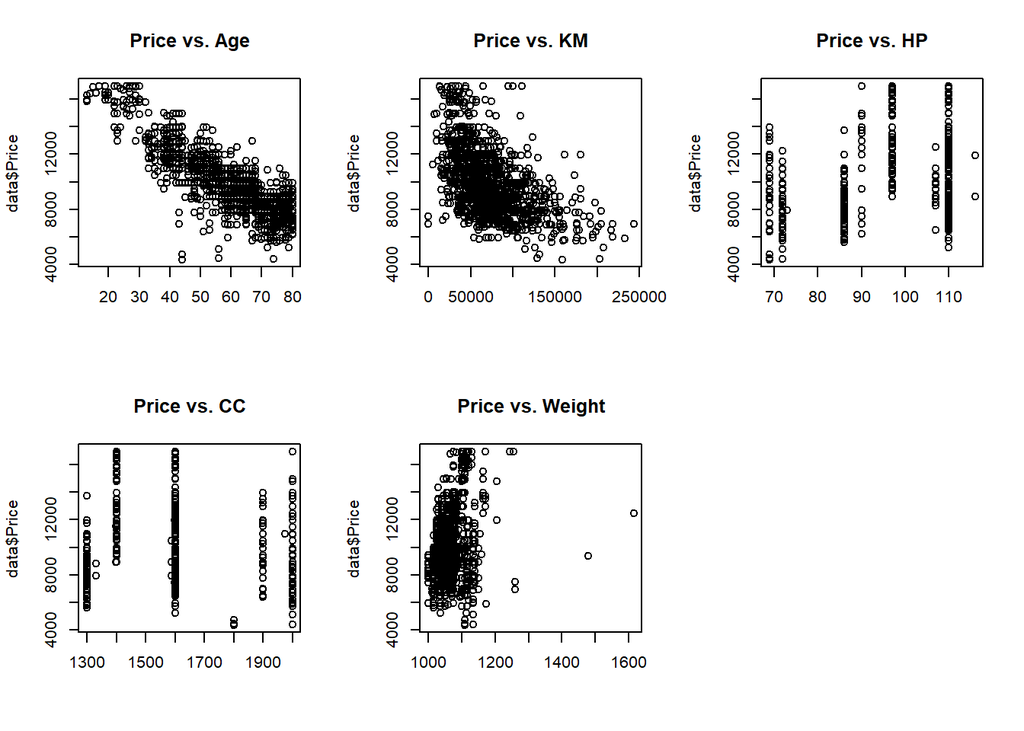

```r
par(mfrow = c(2, 3))
for(i in c(2, 3, 5, 8, 10)){
    plot(data[,i], data$Price, xlab='', main=paste('Price vs.', colnames(data)[i]))
}
par(mfrow = c(1, 1))
```

# 5 Data PreProcessing

## 5.1 Divide Dataset into Train and Test randomly

Learn model in Train dataset

Evaluate model performance in Test dataset

```r
set.seed(123456)
train_cases <- sample(1:nrow(data), nrow(data) * 0.7)  # according to the dataset size: 70% - 30%
train <- data[train_cases, ]
test <- data[-train_cases, ]
```

Train data distribution must be similar to test data distribution

```r
dim(train)
```

```
## [1] 927  10
```

```r
summary(train)
```

```
##      Price            Age              KM           FuelType         HP
##  Min.   : 4450   Min.   :13.00   Min.   :     1   CNG   : 13   Min.   : 69.0
##  1st Qu.: 8250   1st Qu.:50.00   1st Qu.: 48566   Diesel: 94   1st Qu.: 86.0
##  Median : 9500   Median :62.00   Median : 67100   Petrol:820   Median :110.0
##  Mean   : 9927   Mean   :59.23   Mean   : 73034                Mean   :100.2
##  3rd Qu.:10950   3rd Qu.:71.00   3rd Qu.: 89992                3rd Qu.:110.0
##  Max.   :16950   Max.   :80.00   Max.   :243000                Max.   :116.0
##  MetColor Automatic       CC       Doors       Weight
##  0:314    0:876     Min.   :1300   2:  1   Min.   :1000
##  1:613    1: 51     1st Qu.:1400   3:431   1st Qu.:1035
##                     Median :1600   4: 88   Median :1065
##                     Mean   :1556   5:407   Mean   :1065
##                     3rd Qu.:1600           3rd Qu.:1076
##                     Max.   :2000           Max.   :1615
```

```r
dim(test)
```

```
## [1] 398  10
```

```r
summary(test)
```

```
##      Price            Age              KM           FuelType         HP
##  Min.   : 4350   Min.   :13.00   Min.   : 10210   CNG   :  4   Min.   : 69
##  1st Qu.: 8250   1st Qu.:49.00   1st Qu.: 44541   Diesel: 38   1st Qu.: 90
##  Median : 9725   Median :62.00   Median : 63543   Petrol:356   Median :110
##  Mean   : 9968   Mean   :59.09   Mean   : 70718                Mean   :101
##  3rd Qu.:11472   3rd Qu.:71.00   3rd Qu.: 87616                3rd Qu.:110
##  Max.   :16950   Max.   :80.00   Max.   :207114                Max.   :110
##  MetColor Automatic       CC       Doors       Weight
##  0:131    0:378     Min.   :1300   2:  1   Min.   :1000
##  1:267    1: 20     1st Qu.:1400   3:162   1st Qu.:1035
##                     Median :1600   4: 42   Median :1060
##                     Mean   :1562   5:193   Mean   :1064
##                     3rd Qu.:1600           3rd Qu.:1080
##                     Max.   :2000           Max.   :1255
```

# 6 Modeling

## 6.1 Train Simple Linear Regression Model 1 (Univariate Regression)

> Based-on previous analysis, it seems that **KM** is important to explain **Price** variance (corr = -52%)

Regress Price on KM

```r
m1 <- lm(Price ~ KM, data = train)
m1  # regression equation
```

```
##
## Call:
## lm(formula = Price ~ KM, data = train)
##
## Coefficients:
## (Intercept)           KM
##   1.236e+04   -3.337e-02
```

```r
summary(m1)  # results of m1 regression model
```

```
##
## Call:
## lm(formula = Price ~ KM, data = train)
##
## Residuals:
##     Min      1Q  Median      3Q     Max
## -5414.1 -1345.9  -320.3  1148.3  8269.7
##
## Coefficients:
##               Estimate Std. Error t value Pr(>|t|)
## (Intercept)  1.236e+04  1.498e+02   82.56   <2e-16 ***
## KM          -3.337e-02  1.839e-03  -18.14   <2e-16 ***
## ---
## Signif. codes:  0 '***' 0.001 '**' 0.01 '*' 0.05 '.' 0.1 ' ' 1
##
## Residual standard error: 2014 on 925 degrees of freedom
## Multiple R-squared:  0.2624, Adjusted R-squared:  0.2616
## F-statistic:   329 on 1 and 925 DF,  p-value: < 2.2e-16
```

> R<sup>2</sup> = 0.2624: 26% of **Price** variance has been explained by **KM**

> Consider the problem context, for price prediction, R<sup>2</sup> = 0.26 is not good model, we need 0.70

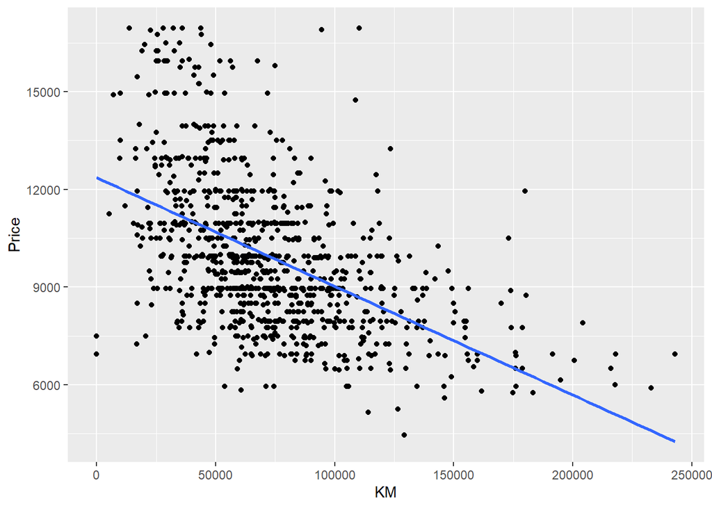

```r
ggplot(train, aes(x=KM, y=Price)) +
    geom_point() +
    geom_smooth(method='lm', se=F)  # variance of 'Price' based-on 'KM' is high around regression line
```

**Main Question**: can we generalize this line to population? -> F-test and then t-test

Check Assumptions of Regression

1. Normality of residuals (Errors)

```r
m1$residuals
```

[output not shown]

[output cut: 255 more lines]

[output not shown]

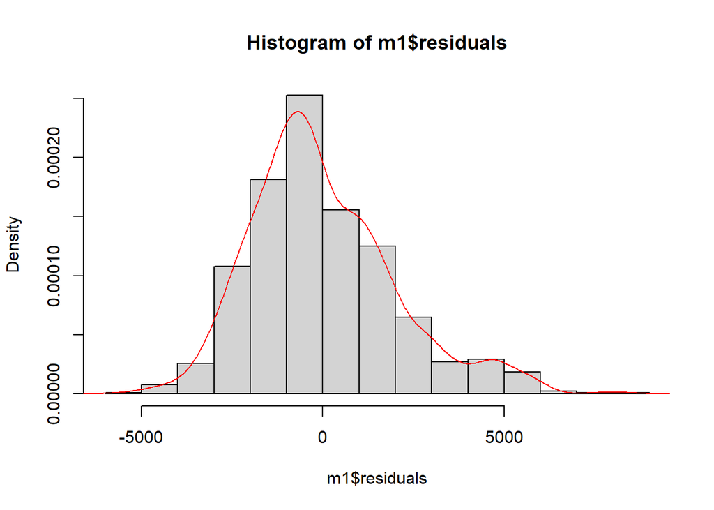

```r
hist(m1$residuals, probability = T)  # skewed to right (have a tail along right)
lines(density(m1$residuals), col='red')
```

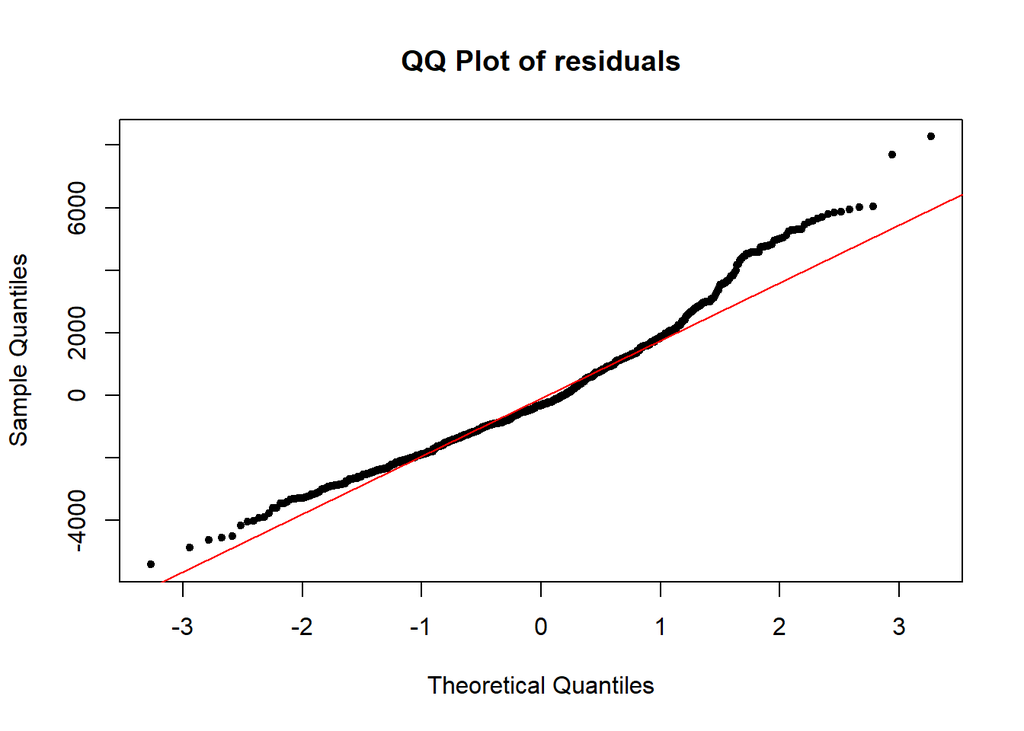

```r
qqnorm(m1$residuals, main='QQ Plot of residuals', pch = 20)  # we have serious deviations from normal distribution
qqline(m1$residuals, col='red')
```

```r
#p-value < 0.05 reject normality assumption
jarque.test(m1$residuals)
```

```
##
##  Jarque-Bera Normality Test
##
## data:  m1$residuals
## JB = 104.66, p-value < 2.2e-16
## alternative hypothesis: greater
```

```r
#p-value < 0.05 reject normality assumption
anscombe.test(m1$residuals)
```

```
##
##  Anscombe-Glynn kurtosis test
##
## data:  m1$residuals
## kurt = 3.7320, z = 3.5512, p-value = 0.0003834
## alternative hypothesis: kurtosis is not equal to 3
```

> **result**: Residuals are not Normally Distributed -> reject first Assumption of Regression
2. Residuals independency

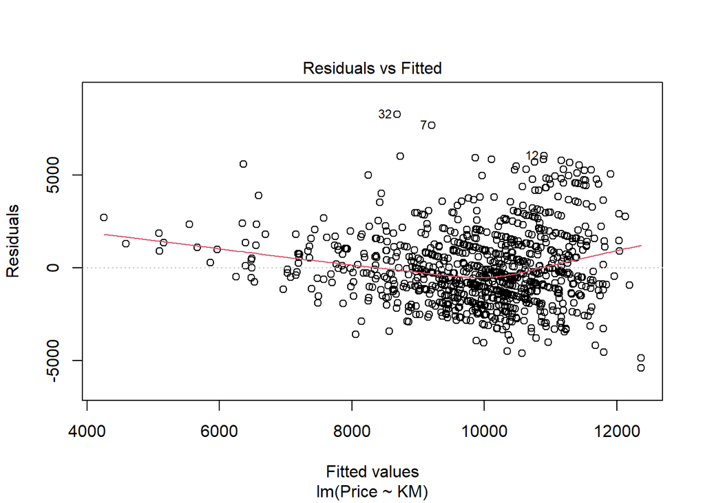

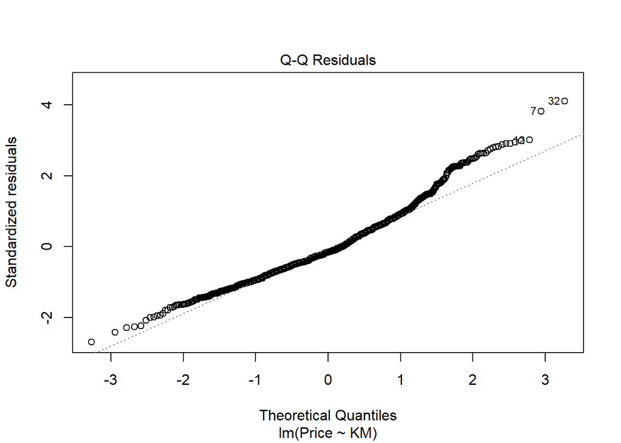

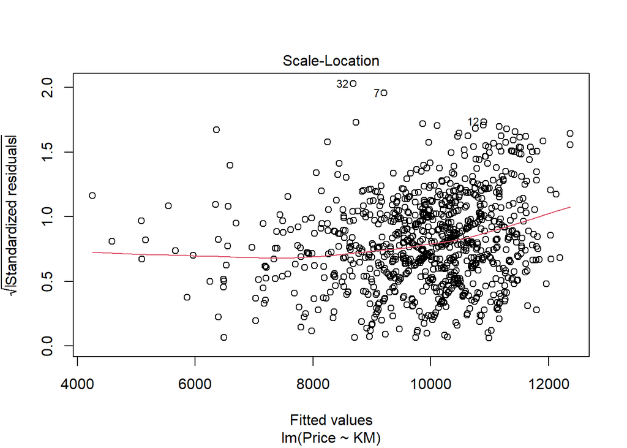

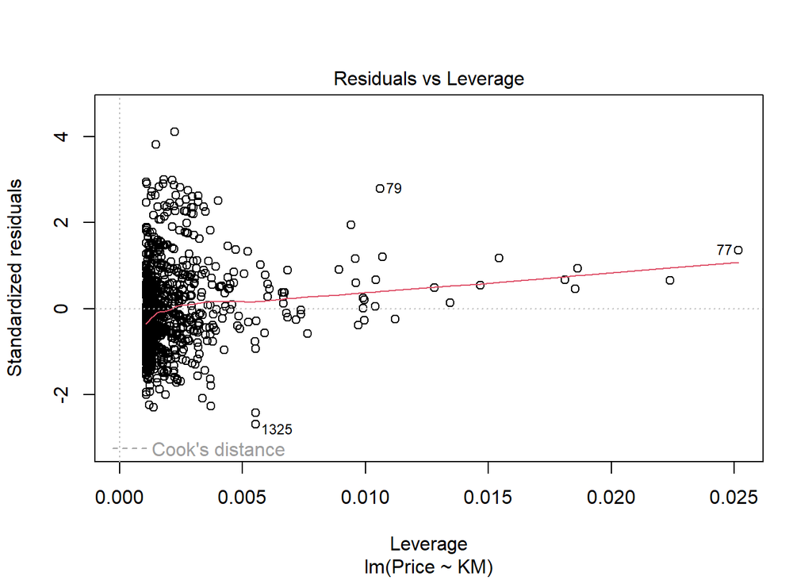

```r
plot(m1)  # Diagnostic Plots
```

> **result**: We see Heteroscedasticity problem in model

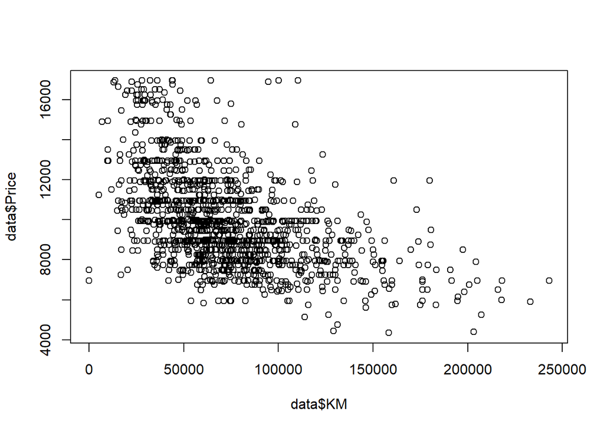

```r
plot(data$KM, data$Price)
```

> It seems that the relationship between these two variable in this sample and this data-range isn’t linear, it is non-linear relationship

so, this model has problem. and t-test results of it are not reliable yet!

## 6.2 Train Simple Linear Regression Model 2 (Multivariate Regression)

```r
m2 <- lm(Price ~ KM + I(KM^2), data = train)  # Quadratic Regression
summary(m2)
```

```
##
## Call:
## lm(formula = Price ~ KM + I(KM^2), data = train)
##
## Residuals:
##     Min      1Q  Median      3Q     Max
## -6587.1 -1330.7  -318.2  1125.0  8505.4
##
## Coefficients:
##               Estimate Std. Error t value Pr(>|t|)
## (Intercept)  1.354e+04  2.580e+02  52.478  < 2e-16 ***
## KM          -6.467e-02  5.932e-03 -10.902  < 2e-16 ***
## I(KM^2)      1.679e-07  3.030e-08   5.541 3.92e-08 ***
## ---
## Signif. codes:  0 '***' 0.001 '**' 0.01 '*' 0.05 '.' 0.1 ' ' 1
##
## Residual standard error: 1983 on 924 degrees of freedom
## Multiple R-squared:  0.2861, Adjusted R-squared:  0.2846
## F-statistic: 185.1 on 2 and 924 DF,  p-value: < 2.2e-16
```

Check Assumptions of Regression

1. Normality of residuals (Errors)

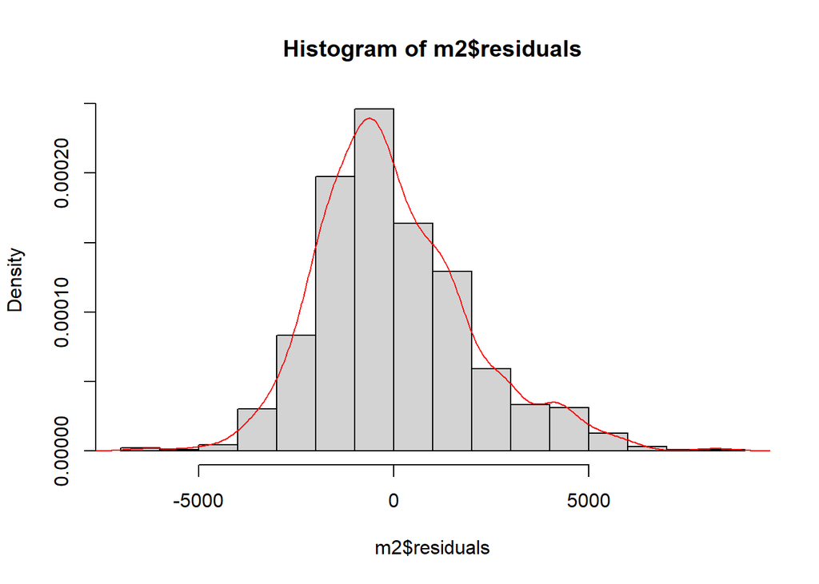

```r
hist(m2$residuals, freq = F)
lines(density(m2$residuals), col = 'red')  # right skewed
```

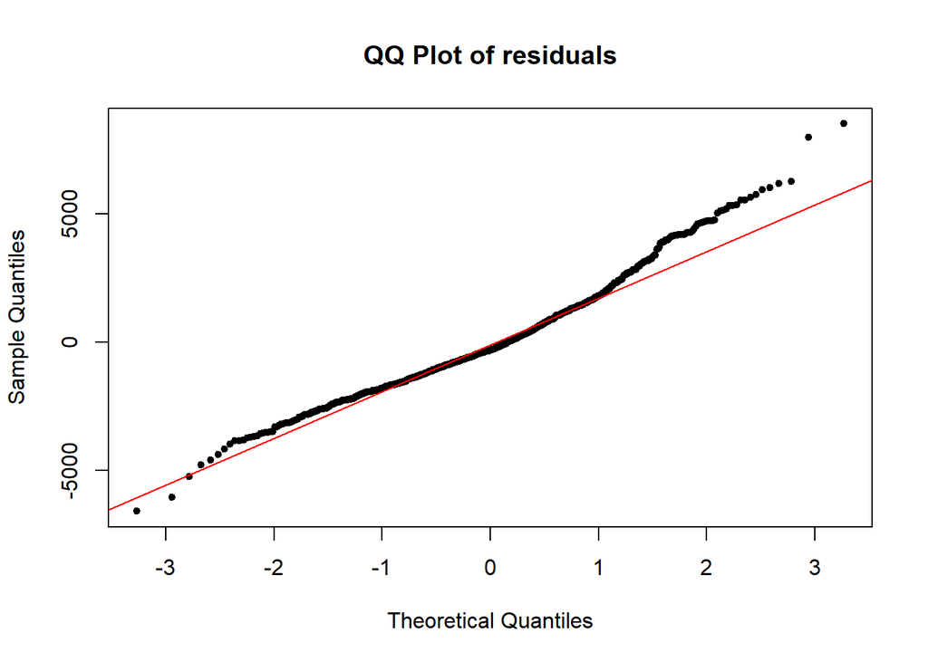

```r
qqnorm(m2$residuals, main = 'QQ Plot of residuals', pch = 20)
qqline(m2$residuals, col = 'red')
```

```r
#p-value < 0.05 reject normality assumption
jarque.test(m2$residuals)
```

```
##
##  Jarque-Bera Normality Test
##
## data:  m2$residuals
## JB = 98.58, p-value < 2.2e-16
## alternative hypothesis: greater
```

```r
#p-value < 0.05 reject normality assumption
anscombe.test(m2$residuals)
```

```
##
##  Anscombe-Glynn kurtosis test
##
## data:  m2$residuals
## kurt = 3.9037, z = 4.1293, p-value = 3.639e-05
## alternative hypothesis: kurtosis is not equal to 3
```

> **result**: Residuals are not Normally Distributed -> reject first Assumption of Regression
2. Residuals independency

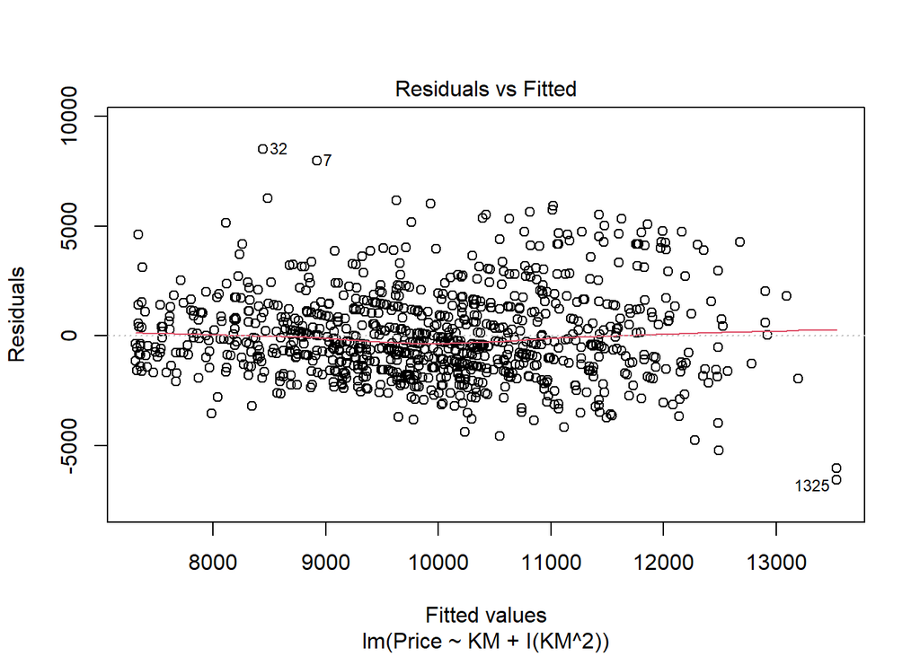

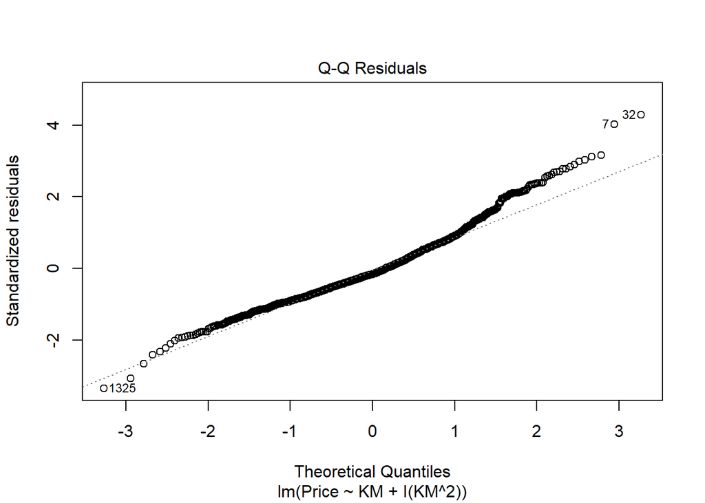

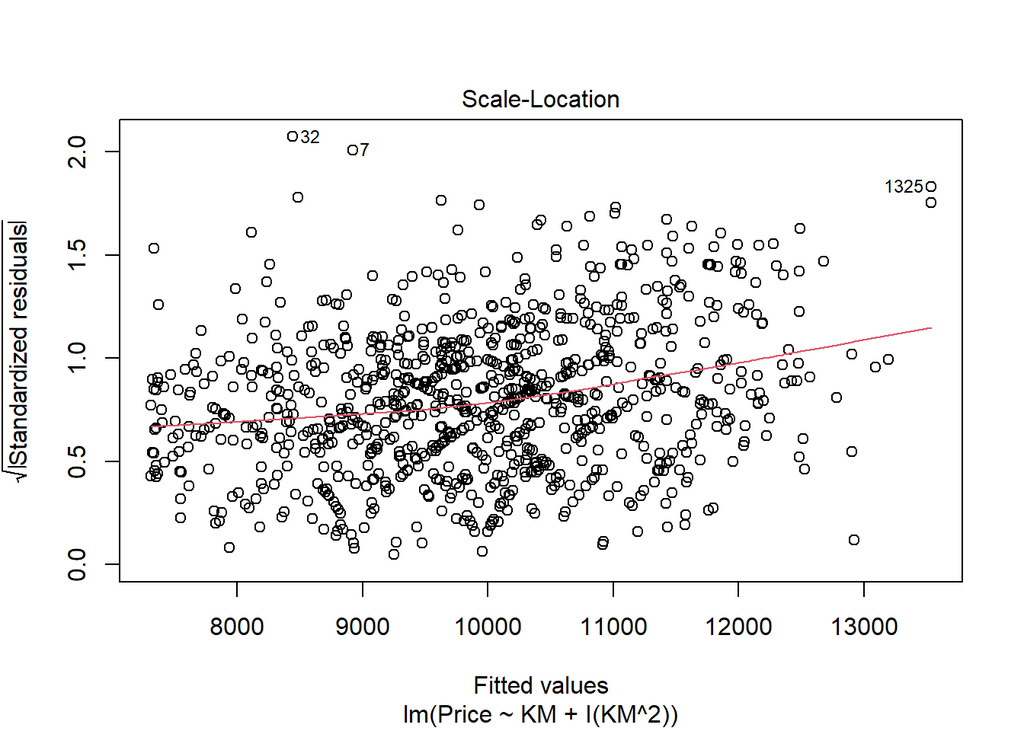

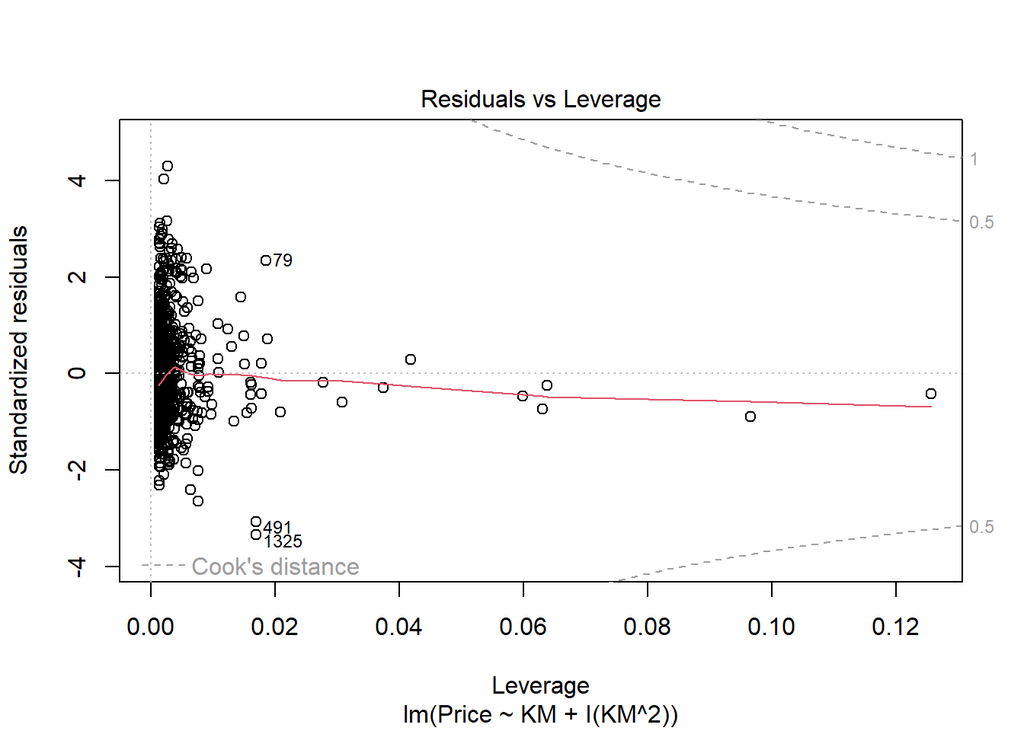

```r
plot(m2)  # Diagnostic Plots
```

Linear vs. Quadratic Regression

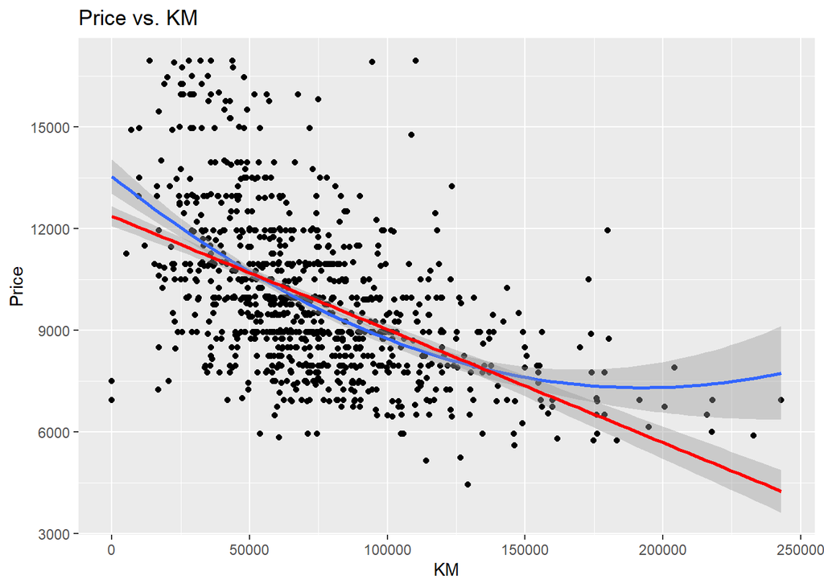

```r
ggplot(train, aes(KM, Price)) +
    geom_point() +
    geom_smooth(method = 'lm', formula = y ~ x + I(x^2)) +
    geom_smooth(method = 'lm', formula = y ~ x, color = 'red') +
    ggtitle('Price vs. KM')
```

Back to errors non-normality problem: maybe some outlier observations make them non-normal (in other words: residuals have not systematic deviations from normal distribution and just some outliers make them non-normal)

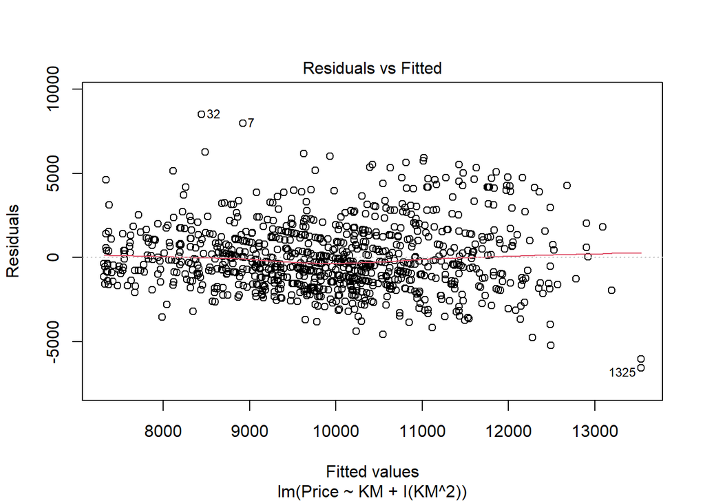

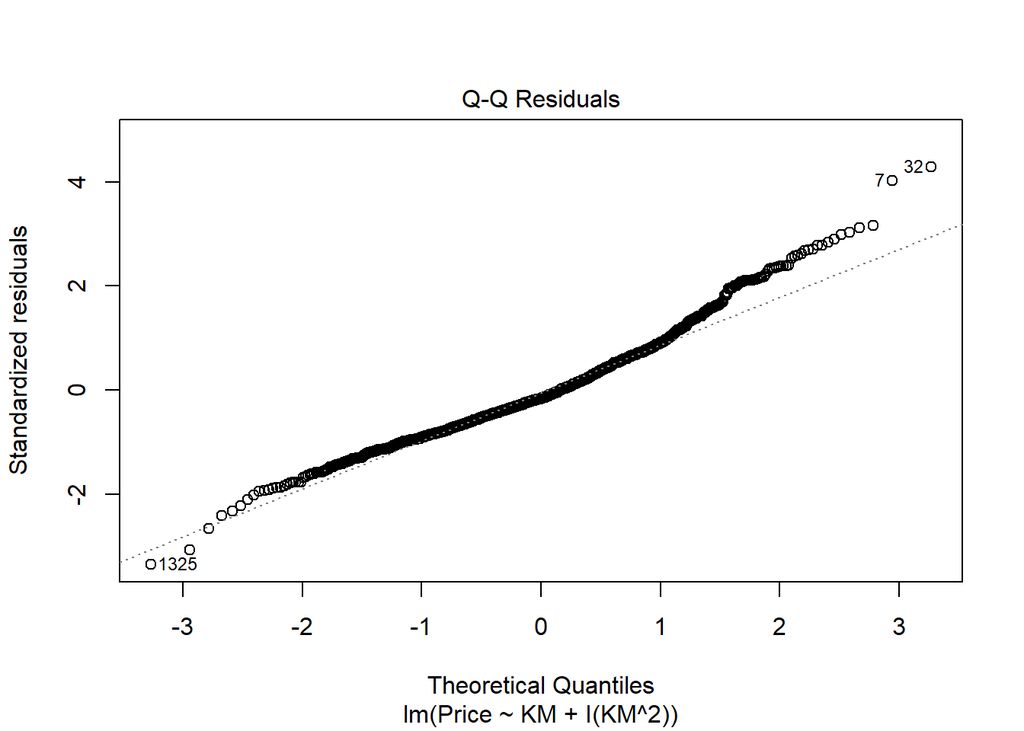

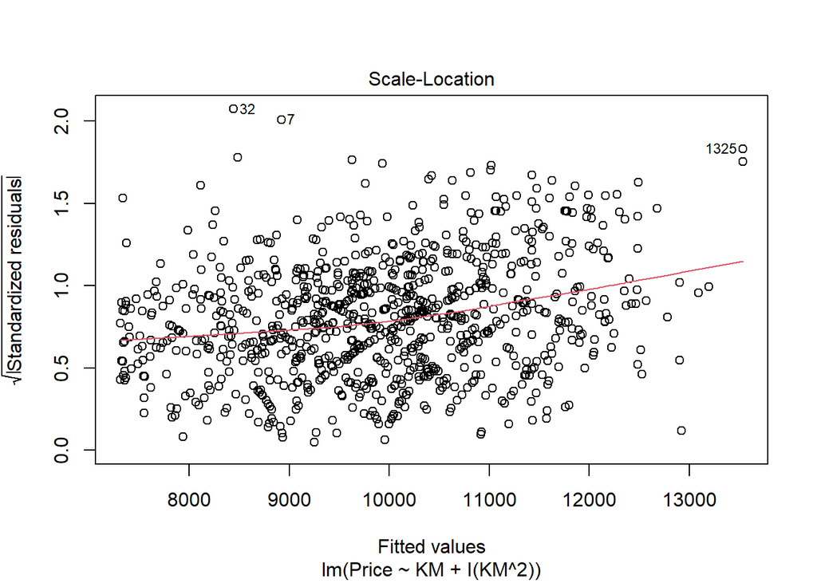

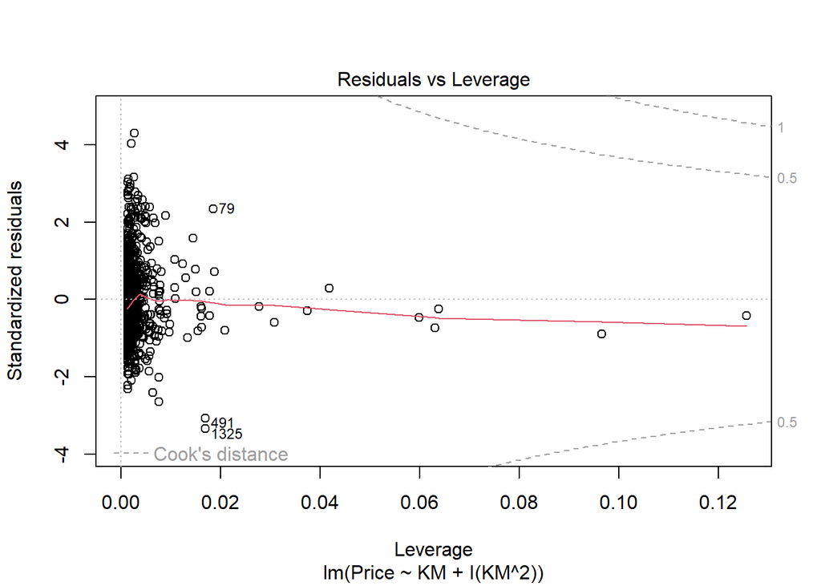

```r
plot(m2)
```

```r
train2 <- train[-which(rownames(train) == 7 | rownames(train) == 32 | rownames(train) == 1325),]  # remove three outliers (based-on residuals QQ-plot) from dataset
```

## 6.3 Model 2_2

```r
m2_2 <- lm(Price ~ KM + I(KM^2), data = train2)
summary(m2_2)
```

```
##
## Call:
## lm(formula = Price ~ KM + I(KM^2), data = train2)
##
## Residuals:
##     Min      1Q  Median      3Q     Max
## -6205.5 -1331.9  -294.5  1138.8  6326.9
##
## Coefficients:
##               Estimate Std. Error t value Pr(>|t|)
## (Intercept)  1.371e+04  2.542e+02  53.925  < 2e-16 ***
## KM          -6.866e-02  5.840e-03 -11.757  < 2e-16 ***
## I(KM^2)      1.849e-07  2.977e-08   6.212 7.93e-10 ***
## ---
## Signif. codes:  0 '***' 0.001 '**' 0.01 '*' 0.05 '.' 0.1 ' ' 1
##
## Residual standard error: 1936 on 921 degrees of freedom
## Multiple R-squared:  0.3072, Adjusted R-squared:  0.3057
## F-statistic: 204.2 on 2 and 921 DF,  p-value: < 2.2e-16
```

Normality of residuals test

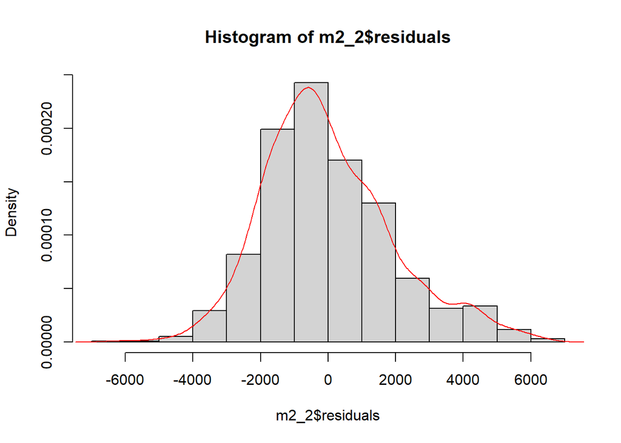

```r
hist(m2_2$residuals, probability = TRUE)
lines(density(m2_2$residuals), col = "red")  # skewed to right
```

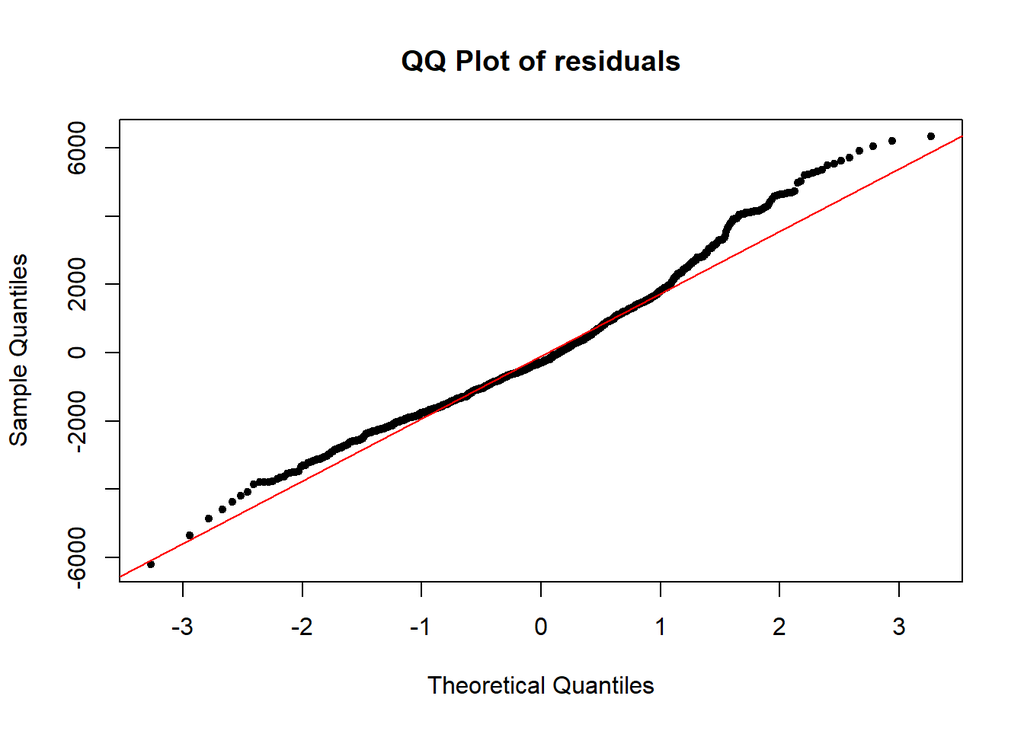

```r
qqnorm(m2_2$residuals, main = "QQ Plot of residuals", pch = 20)
qqline(m2_2$residuals, col = "red")
```

```r
#p-value < 0.05 reject normality assumption
jarque.test(m2_2$residuals)
```

```
##
##  Jarque-Bera Normality Test
##
## data:  m2_2$residuals
## JB = 58.137, p-value = 2.376e-13
## alternative hypothesis: greater
```

```r
#p-value < 0.05 reject normality assumption
anscombe.test(m2_2$residuals)
```

```
##
##  Anscombe-Glynn kurtosis test
##
## data:  m2_2$residuals
## kurt = 3.4431, z = 2.4172, p-value = 0.01564
## alternative hypothesis: kurtosis is not equal to 3
```

> **result**: errors are not normally distributed

> **Note**: Deviation from normality assumption got improved (because we remove 3 outliers)

so, maybe Deviation from normality is just because some observations (and if remove more outliers, it will become normal)

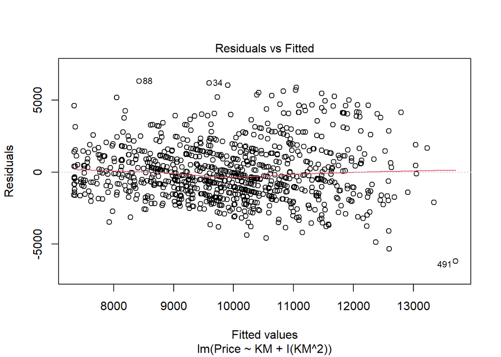

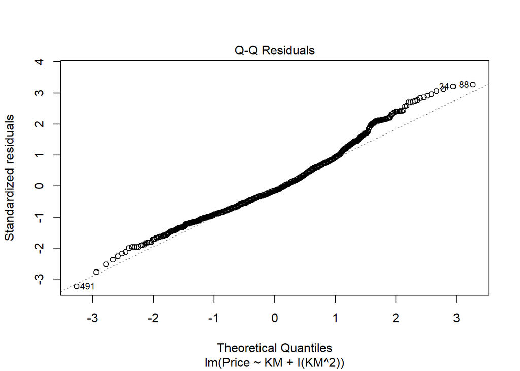

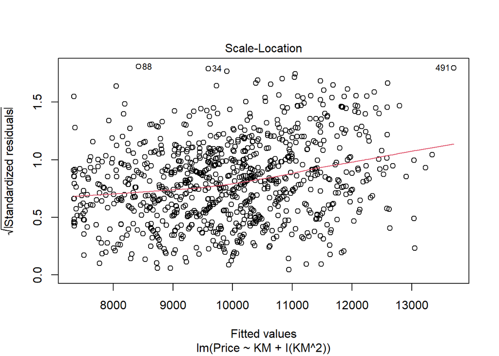

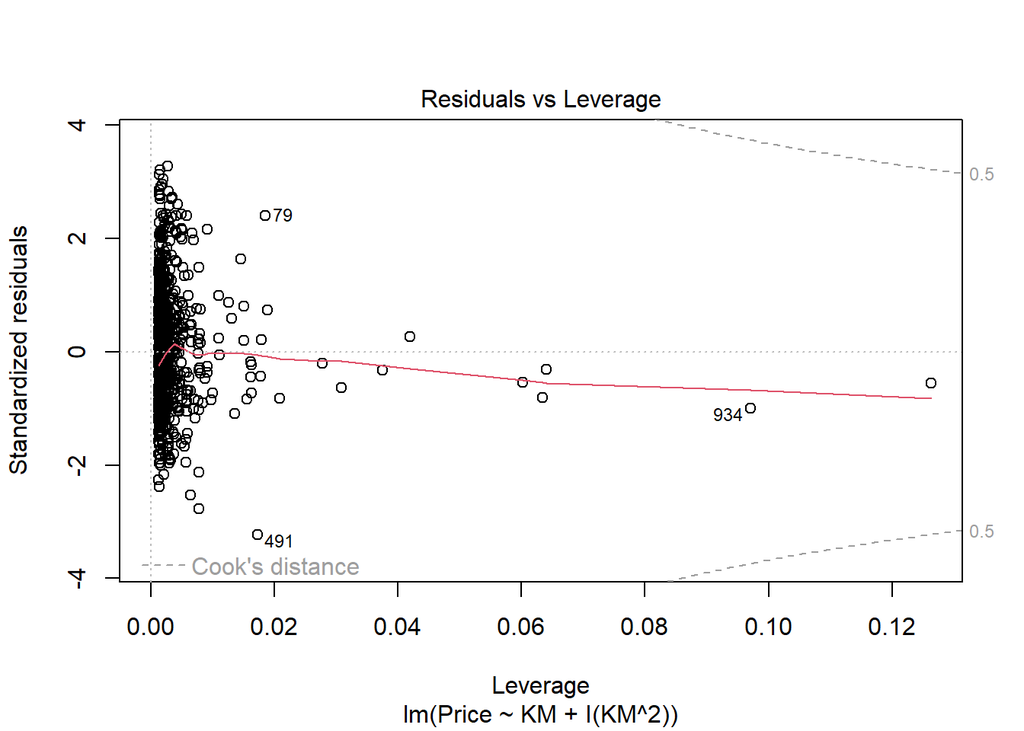

```r
plot(m2_2)  # Diagnostic Plots
```

How we measure|detect multicollinearity? use VIF index

If VIF > 10 then multicollinearity problem is high (big VIF is bad)

```r
car::vif(m2)
```

```
##       KM  I(KM^2)
## 10.73222 10.73222
```

```r
car::vif(m2_2)
```

```
##       KM  I(KM^2)
## 10.85026 10.85026
```

Scale ‘KM’ to solve VIF

```r
train$KM_scaled <- scale(train$KM)  # Z-Normalization
head(train)
```

|  | Price | Age | KM | FuelType | HP | MetColor | Automatic | CC | Doors | Weight | KM_scaled |
| --- | --- | --- | --- | --- | --- | --- | --- | --- | --- | --- | --- |
| 1084 | 7500 | 78 | 89953 | Petrol | 110 | 0 | 0 | 1600 | 5 | 1114 | 0.47016154 |
| 234 | 11950 | 41 | 29056 | Petrol | 97 | 1 | 0 | 1400 | 5 | 1060 | -1.22212888 |
| 1066 | 9250 | 80 | 93841 | Petrol | 110 | 0 | 0 | 1600 | 5 | 1070 | 0.57820668 |
| 1150 | 7950 | 72 | 75840 | Petrol | 86 | 0 | 0 | 1300 | 5 | 1035 | 0.07796989 |
| 711 | 8450 | 64 | 70116 | Petrol | 110 | 1 | 0 | 1600 | 4 | 1035 | -0.08109657 |
| 237 | 13450 | 40 | 28362 | Petrol | 110 | 1 | 0 | 1600 | 3 | 1040 | -1.24141472 |